# Resolution in species distribution models shapes spatial patterns of plant multifaceted diversity - Chauvier - Ecography - Wiley Online Library

[Ecography](https://onlinelibrary.wiley.com/journal/16000587)

[Early View](https://onlinelibrary.wiley.com/toc/16000587/0/0) e05973

[figure not shown]

Research

Open Access

# Resolution in species distribution models shapes spatial patterns of plant multifaceted diversity

[Yohann Chauvier](https://onlinelibrary.wiley.com/action/doSearch?ContribAuthorRaw=Chauvier%2C+Yohann),

[Patrice Descombes](https://onlinelibrary.wiley.com/action/doSearch?ContribAuthorRaw=Descombes%2C+Patrice),

[Maya Guéguen](https://onlinelibrary.wiley.com/action/doSearch?ContribAuthorRaw=Gu%C3%A9guen%2C+Maya),

[Louise Boulangeat](https://onlinelibrary.wiley.com/action/doSearch?ContribAuthorRaw=Boulangeat%2C+Louise),

[Wilfried Thuiller](https://onlinelibrary.wiley.com/action/doSearch?ContribAuthorRaw=Thuiller%2C+Wilfried),

[Niklaus E. Zimmermann](https://onlinelibrary.wiley.com/action/doSearch?ContribAuthorRaw=Zimmermann%2C+Niklaus+E),

First published: 07 September 2022

https://doi.org/10.1111/ecog.05973

## Abstract

Species distribution models (SDMs) are statistical tools that relate species observations to environmental conditions to retrieve ecological niches and predict species' potential geographic distributions. The quality and robustness of SDMs clearly depend on good modelling practices including ascertaining the ecological relevance of predictors for the studied species and choosing an appropriate spatial resolution (or ‘grain size'). While past studies showed improved model performance with increasing resolution for sessile organisms, there is still no consensus regarding how inappropriate resolution of predictors can impede understanding and mapping of multiple facets of diversity. Here, we modelled the distribution of 1180 plant species across the European Alps for two sets of predictors (climate and soil) at resolutions ranging from 100-m to 40-km. We assessed predictors' importance for each resolution, calculated taxonomic (TD), relative phylogenetic (rPD) and functional diversity (rFD) accordingly, and compared the resulting diversities across space. In accordance with previous studies, we found the predictive performance to generally decrease with decreasing predictor resolution. Overall, multifaceted diversity was found to be strongly affected by resolution, particularly rPD, as exhibited by weak to average linear relationships between 100-m and 1-km resolutions (0.13 ≤ R<sup>2</sup> ≤ 0.57). Our results demonstrate the necessity of using highly resolved predictors to explain and predict sessile species distributions, especially in mountain environments. Using coarser resolution predictors might cause multifaceted diversity to be strongly mispredicted, with important consequences for biodiversity management and conservation.

## Introduction

Over the last decades, losses of global biodiversity have severely escalated as a result of increasing biotic homogenization, overexploitation, pollution, habitat fragmentation, climate and land use changes (Vitousek 1994, McKinney and Lockwood 1999, Gibbon et al. 2000, Butchart et al. 2010, Steffen et al. 2011, Hooper et al. 2012). These biodiversity losses have altered ecosystem functioning, stability and service provisioning upon which modern society depends on (Worm et al. 2006, Cardinale et al. 2012), and conservation initiatives and planning are rising to counteract this decay of our natural heritage (McIntosh et al. 2017, Mills et al. 2019). Species distribution models (SDMs) are invaluable tools for conservation purposes and other ecological disciplines (Guisan et al. 2013, Mateo et al. 2019, Pollock et al. 2020). SDMs predict the potentially suitable areas of species in space by relating their observations to environmental and/or anthropogenic predictors (Guisan and Zimmerman 2000, Guisan and Thuiller 2005, Elith and Leathwick 2009). As such, SDMs bear decisive information for improved species and biodiversity management, provided that good modelling practices are followed (Loiselle et al. 2003, Araújo et al. 2019, La Marca et al. 2019, Brun et al. 2020, Helmstetter et al. 2021). Integrating meaningful categories of environmental predictors (Thuiller et al. 2004, Coudun et al. 2006, Buri et al. 2020, Chauvier et al. 2021a) is as crucial as decisions on model calibration and evaluation to ensure robust SDM outputs. However, choosing the adequate scale of predictors (i.e. resolution and extent) is also essential (Guisan and Thuiller 2005, Elith and Leathwick 2009), and related consequences on predicted species distributions and diversity patterns in response to predictor resolution have received little attention so far.

SDMs need to be calibrated with environmental variables at appropriate spatial ‘resolution' or ‘grain size' for sound predictive outputs (Levin 1992, Randin et al. 2009). This resolution needs to be consistent with the resolution or coordinate accuracy of the species distribution data, as well as capturing the relevant biological scale of the system and species studied; e.g. when modelling sessile species. Therefore, species of low mobility (e.g. plants, soil invertebrates) likely require more highly resolved spatial predictors than more mobile species (e.g. birds, large carnivores) so that the spatial details in their niche may be accurately assessed (Huston 2002, Guisan and Thuiller 2005, Austin 2007, Elith and Leathwick 2009, Araújo et al. 2019). Habitat fragmentation, land use, geology (≤ 1 km; Domisch et al. 2015), species interactions, topography and soil ecological conditions (≤ 100-m) mostly exhibit finer-scale spatial variability which influences species distributions and abundances over short distances. In contrast, climate is expected to have a pronounced regional effect on species distributions because of its known large-scale variability (≥ 1-km grain, or meso-climate), but micro-climate has also been highlighted as a crucial driver of plant distribution at finer scale, particularly in mountainous environments (Engler et al. 2009, Franklin et al. 2013, Lembrechts et al. 2019b). Overall, high-resolution predictors have shown to significantly improve model performance and spatial predictions of plant distributions (Buri et al. 2017, Meineri and Hylander 2017). The use of highly resolved predictors is therefore an important prerequisite of SDMs specifically for sessile species, since they respond to heterogeneous micro-environments that are not captured at coarser resolution (Scherrer and Körner 2011, Moudrý and Šímová 2012, Descombes et al. 2016).

A large array of studies has assessed model performances for different environmental resolutions. Although a general decrease with decreasing resolution was found, these studies did not test a broad range and number of resolutions (Guisan et al. 2007, Seo et al. 2009, Pradervand et al. 2014, Farashi and Alizadeh-Noughani 2018, Manzoor et al. 2018) for a large number of actual species: i.e. non-virtual and sessile species (Gottschalk et al. 2011, Lauzeral et al. 2013, Khosravi et al. 2016, Scales et al. 2017, Connor et al. 2018, Friedrichs-Manthey et al. 2020). Also, no study ever explicitly compared SDM performances across resolutions for large and small-scale predictors (e.g. climate and soil), or evaluated their importance in predicting species distributions (but see Connor et al. 2018). Exploring the importance of predictors at varying resolutions remains essential to understand which (categories of) predictors are more likely to explain and predict more efficiently a species' response at a specific spatial resolution. This is especially true if SDM predictive outputs are used for conservation planning and other ecological applications from regional to local scales.

Inadequate selection of resolution relative to the available distribution data and the species studied might lead to wrong spatial diversity assessments. Not only taxonomic diversity (TD), but additional metrics increasingly used in conservation and other ecological fields depend on resolution. For instance, phylogenetic diversity (PD) defines the shared evolutionary history among species (Faith 1992), while functional diversity (FD) reflects the diversity of morphological and ecophysiological traits in a given community (Petchey and Gaston 2002). Although a few studies have empirically shown that multifaceted diversity and endemism are scale dependent (Thuiller et al. 2015, Jarzyna and Jetz 2018, Daru et al. 2020), we still lack a clear understanding of how spatial multifaceted diversity may spatially be impacted when modelling species distributions at different resolutions. On the one hand, erroneous modelling of species extinctions has already been highlighted when predicting plant species at too coarse a resolution (Randin et al. 2009, Hannah et al. 2014), giving us preliminary leads that TD might be underestimated if modelling species distributions at lower resolution. On the other hand, anticipating how such changes in TD might spatially impact PD and FD remains very complex, due to their mutual independence (Forest et al. 2007, Devictor et al. 2010) and the different evolutionary histories and functional roles of species. Overall, we lack a clear understanding of how varying resolution affects plant multifaceted diversity patterns, and the potential consequences for various ecological studies.

Here, we investigated the predictive performance and relative importance of environmental predictors for SDMs across 41 resolutions (100-m to 40-km), assessed for two categories of predictors (climate and soil) and for 1180 plant species across the European Alps. More than 1.3 million models were fitted within an ensemble modelling approach spanning three different statistical algorithms, and evaluated with the true skill statistics (TSS) using block split sampling. Magnitude of changes in plant species, phylogenetic and functional diversity were estimated between modelled predictions at 100-m resolution and five selected coarser resolutions (1, 10, 20, 30 and 40-km).

## Material and methods

### Study area and species observations

The study area covered the official Alpine Convention perimeter (Permanent Secretariat of the Alpine Convention 2009) with a total area of 257 672 km<sup>2</sup>. Our dataset of observations was gathered from more than 210 individual sources, with largest contributions from the National Data and Information Centre on the Swiss Flora (InfoFlora; ~48%), the French National Alpine Botanical Conservatory (~19%), the French National Mediterranean Botanical Conservatory (~5%) and the Global Biodiversity Information Facility (<https://doi.org/10.15468/dd.a2u6rg>; ~2%). All datasets were merged after unifying the species taxonomy, and GBIF geo-referenced observations > 100-m precision were removed after a preliminary filtering (Chauvier et al. 2021a, b2022 for more information on dataset and methods). In total, the compiled observational dataset contained 6 523 980 records (~99.96% with ≤ 100-m uncertainty) for 3560 species. The dataset was further filtered according to preliminary checks: 1) for each species, we summarized observations per 40-km grid cell, and 2) species occurring in less than 50 grid cells were removed. Our final observational dataset comprised 5 595 759 observations for 1180 species (Fig. 1a, b). For each species, we extracted additional information from Flora Alpina (Aeschimann et al. 2004) about elevation (colline, montane, sub-alpine, alpine and nival species) and geological preferences (calcareous, siliceous and mixed species; see Supporting information for numerical details).

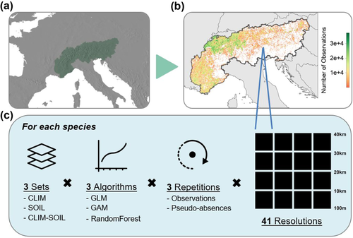

**Figure 1**

Open in figure viewer[PowerPoint](https://onlinelibrary.wiley.com/action/downloadFigures?id=ecog12912-fig-0001&doi=10.1111%2Fecog.05973)

Summary of our study framework. Panel (a) represents the study area in green shading. Panel (b) shows the distribution of species observation density across the study area; i.e. a final observational dataset of 5 595 759 observations for 1180 species. Distribution of the density was aggregated at a 3-km resolution for better visual representation, and displayed log-transformed per pixel. Panel (c) shows the methodological pipeline of the study. For each species, models were calibrated for 41 different spatial resolutions (100-m to 40-km with a 1-km step), three sets of predictors (CLIM: climate predictors; SOIL: soil predictors; CLIM–SOIL: both predictors) and three statistical algorithms. Each model was repeated three times, i.e. by resampling without replacement a new set of observations and pseudo-absences per grid cell. GLM, generalized linear model; GAM, generalized additive model.

### Environmental data

#### Climate variables

We used three climate predictors at a 100-m resolution over the European Alps. 1) Annual solar radiation was obtained from sky view factors (SVFs) employing the System for Automated Geoscientific Analyses (SAGA GIS; Conrad et al. 2015) and the Digital Elevation Model over Europe at 30-m resolution from the GMES RDA project (EU-DEM, <www.eea.europa.eu/data-and-maps/data/>). It was corrected to actual radiations with cloud cover (mean values over the time period 2000–2014) at 1-km resolution from the EarthEnv project (Wilson and Jetz 2016). 2) Annual precipitation sum and 3) minimum temperature of the coldest month (mean values over the time period 1979–2013) were extracted from the climatologies at high resolution for the earth's land surface areas (CHELSA) portal (Karger et al. 2017, <https://chelsa-climate.org/>). Based on the extent of the study area, each predictor was downscaled from 1-km to a 100-m resolution (see Appendix S2 in von Oppen et al. 2021 for more details on the downscaling procedure). Downscaling of radiation and precipitation was achieved by applying geographically weighted regressions (GWR) relative to the EU-DEM (Danielson and Gesch 2011). Downscaling of temperature was achieved by first calculating lapse rates from the ERA5 global reanalysis data (Hersbach et al. 2020). Minimum surface temperature was then estimated as a function of air temperature, lapse rate and solar radiation to better account for variation due to topography and elevation (Wilson and Gallant 2000).

#### Soil variables

We derived soil property layers at a 100-m resolution over the study area by mapping ecological indicator values (EIVs; Ellenberg et al. 1991, Landolt et al. 2010) in space following the method described in Descombes et al. (2020). Based on the plant EIVs of our 3560 species extracted from Flora Alpina (Aeschimann et al. 2004) and all related observations (n = 6 523 980 records), indicator value maps for soil pH (pH), soil nitrogen (Nitrogen) and soil moisture (Humidity) were generated using Random Forest as described in the Supporting information. The generated EIV soil property layers are proxies of soil pH, moisture and nitrogen, and have been shown to be excellent predictors of plant species distribution in SDMs (Descombes et al. 2020).

#### Variable aggregation to coarser resolutions

All 100-m climate and soil predictors showed acceptable correlations (|r|<sub>max</sub> = 0.75; Supporting information) were projected over the study area to the standard Lambert Azimuthal Equal Area projection for Europe (EPSG:3035) and aggregated through averaging to 40 incremental coarser spatial resolutions; i.e. 1–40 km at 1-km intervals. In total, the candidate list of environmental predictors, used for analysis and modelling of species distributions, consisted of three climate and three soil variables available at 41 different spatial resolutions.

### Model calibration

#### Study framework

For each of the 1180 species and 41 spatial resolutions, we ran a set of models with only climate (CLIM), only soil (SOIL) and both predictor sets (CLIM–SOIL). For each set, we ran three SDM algorithms: generalized linear models (GLM; McCullagh 1984), generalized additive models (GAMs; *mgcv* R package; Hastie and Tibshirani 1990, Wood 2017) and RandomForest (*RandomForest* R package; Breiman 2001). These algorithms were chosen to reflect inter-model variability that can influence model performance and predictive output (Thuiller et al. 2019, Brun et al. 2020). Furthermore, an intermediate level of model parameter complexity was kept for the three algorithms, to avoid calibrating models that would under- or over-fit species' responses to the environment (Merow et al. 2014, Brun et al. 2020). GLMs were run with first and second order polynomial terms, GAMs were calibrated using smooth terms with a maximum of four degrees of freedom and RandomForests were trained using 1000 trees and by setting the minimum number of observations in the terminal nodes to 10 (adapted from Brun et al. 2020).

#### Resolution and sampling bias

For each individual model, only one observation was selected per 40-km grid cell. Each selection was repeated three times, by resampling one species observation randomly without replacement per 40-km grid cell (Fig. 1c). This was done to ensure a balanced observation prevalence (i.e. number of presence records per model resolution) in model calibration across the 41 different resolutions. This sampling procedure avoided the predictive performances being affected by varying numbers of observations across resolutions, and consequently allowed for a better representation of the environmental space across the study area.

As no true absences were available, we chose to sample pseudo-absences according to the density target group approach (using the density pattern of all 6 523 980 species records; Righetti et al. 2019). This allowed us to mimic the same general spatial bias for pseudo-absences as for presence observations (Phillips et al. 2009). Similar to observations, 10 000 pseudo-absences were sampled randomly without replacement over the study area for each model repetition. Pseudo-absences were then combined with presences and weighted equally to presences in model calibrations, by using the weight and sample size parameters for GLM/GAM and RandomForest, respectively (Barbet-Massin et al. 2012, Kuhn and Johnson 2013). Based on this procedure, presences had the same weight as pseudo-absences across resolutions, allowing the influence of pseudo-absences in all model calibrations to be kept constant, regardless of their number and that of observations.

### Model evaluation

We assessed the predictive performance of each model repetition under a five-fold spatial block split sampling (Roberts et al. 2017). This enabled us to to preliminarily delineate independent spatial blocks to partition observations in geographic space, which can be done either regularly (Roberts et al. 2017) or according to observational pattern (Brun et al. 2020). For each model repetition, observations were evenly partitioned into ten five-fold blocks spatially stratified (two blocks per fold) using species observation coordinates and partitioning around medoids (PAM) clustering (following Brun et al. 2020). This allowed the number of observations to be spatially and numerically balanced within each independent fold. Model performance was then evaluated using presences and pseudo-absences of the left-out fold and the True Skill Statistics (TSS; Allouche et al. 2006).

### Analyses

#### Variable importance

The relative importance (%) of our climate and soil variables in predicting species distributions was measured across the 41 resolutions for each species, algorithm, repetition and fold. The importance analysis was assessed exclusively with the CLIM–SOIL models, since these incorporate both climate and soil predictors. For each calibrated model, seven sets of predictions were computed based on 20 000 points sampled across the study area: one set including values of the original predictors, and the six others permuting values of each predictor. Each variable's importance was then calculated by applying a Pearson's correlation r between the original predicted probabilities and the six randomized ones. The score obtained was computed as 1 − |r|, averaged for each species across resolution, and standardized in percentage relative to the other variables' importance (following Thuiller et al. 2009, Descombes et al. 2016).

#### Taxonomic diversity

For each species, predictor set, algorithm, repetition and fold, calibrated models were projected across the study area at six different resolutions: 100-m, 1, 10, 20, 30 and 40-km. All layers of projected presence probabilities were converted to binary layers of presences/absences using the best TSS threshold.

For each species, predictor set and five resolutions (1, 10, 20, 30 and 40-km), binary layers (across the three algorithms, three repetitions and five folds) were summed and presences were assigned to pixels when at least half the models predicted so (committee averaging; Araújo and New 2007, Thuiller et al. 2009, Guisan et al. 2017). For each predictor set and resolution, 1180 species distributions were obtained that way and stacked, to obtain in total 15 taxonomic diversity (TD) distributions across the study area.

The same procedure was applied for the 100-m resolution. However, to adequately compare TD at 100-m and at the five other resolutions, for each set of predictors, we additionally aggregated each species 100-m binary distribution to 1, 10, 20, 30 and 40-km resolution. To this end, an aggregated grid cell was considered a presence if at least one 100-m cell was predicted a presence. For each set of predictor and aggregated resolution, 1180 aggregated species distributions were obtained additionally and stacked, to obtain in total 15 aggregated TD distributions across the study area.

Finally, for additional comparative analyses (Supporting information), TD at 100-m was also spatially averaged to a 1-km resolution (‘100 × 100 m mean') using a bilinear projection and the Geospatial Data Abstraction Library (GDAL; <https://gdal.org/>). In summary, 31 TD layers were used for further analyses.

#### Functional diversity

Functional diversity (FD) was generated over the same species distributions by 1) using a compiled database of plant traits, 2) filling gaps of missing data by applying imputation methods, 3) building a functional tree and 4) calculating FD based on this tree (see Supporting information for more details on the following).

- 1) Based on a compilation of trait data from various sources, values of mean plant height, leaf dry matter content (LDMC), specific leaf area (SLA) and leaf carbon to nitrogen ratio (C:N) were extracted for modelled species having phylogenetic information (i.e. 3442 traits for 1109 species). In total, at least one trait was missing for about 697 species (~22% of total missing values).
- 2) To avoid removing these species from our analysis, we therefore imputed missing trait values with the *Rphylopars* R package (function *phylopars*; Goolsby et al. 2017), which has demonstrated good performance of trait data imputation (Penone et al. 2014, Johnson et al. 2020).
- 3) Based on the four trait values per species, a Gower's distance matrix was constructed (Pavoine et al. 2009, Maire et al. 2015) to build a functional dendrogram using the *cluster* R package (function *daisy*; Maechler et al. 2019). We ran a Mantel test using 9999 randomizations (*vegan* R package, function *mantel*; Oksanen et al. 2013), and found the functional dendrogram to express 83% of the initial distance matrix (r = 0.83; *** p-value < 0.001), indicating a strong conservation of the original functional space.
- 4) Finally, based on the same species distributions employed to generate TD and PD, FD was spatially calculated, similar to PD (function *pd*), although here without including the root (following Petchey and Gaston 2006). Like PD, FD is not independent from TD. Therefore, the same residual analysis from a linear model as with PD was applied to generate 31 layers of relative functional diversity (rFD; Pavoine et al. 2013, Pardo et al. 2017).

## Results

The predictive performance of the ensemble models of our 1180 plant species severely decreased from the 100-m to the 40-km resolution, irrespective of the predictor set used (Fig. 2). While SOIL performed better than CLIM for all resolutions, the drop in model performance from 100-m to 1-km resolution was larger for SOIL and CLIM–SOIL than for CLIM (0.07 versus 0.03; Fig. 2a–c). Overall, the decrease in performance was significant for decreasing resolution starting from 100-m resolution, and only became statistically insignificant at ca 10-km resolution for all predictor sets and individual algorithms (Supporting information).

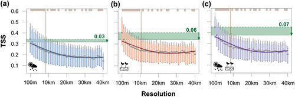

**Figure 2**

Open in figure viewer[PowerPoint](https://onlinelibrary.wiley.com/action/downloadFigures?id=ecog12912-fig-0002&doi=10.1111%2Fecog.05973)

True skill statistics (TSS) of ensemble models of 1180 plant species for 41 resolutions (100-m to 40-km). Ensemble models were fitted with climate (a), soil (b) and climate and soil predictors (c). Green horizontal bars represent performance drops from 100-m to 1-km resolution. Wilcoxon paired-sample one-tailed tests (‘greater') of mean performances were successively performed between increasingly larger neighbouring resolutions (starting at 100-m against 1-km and ending with 39-km against 40-km resolutions). Obtained p-values were adjusted for multiple comparisons (40 total) applying a ‘Bonferroni' correction. Significant differences of mean model performances (* p-value < 0.05) are indicated by a grey bar at the top of each panel. Vertical grey lines highlight the first insignificant comparisons among neighbouring resolutions. Trend curves were fitted with a generalized additive model (GAM) with three degrees of freedom in the smooth term.

Overall minimum temperature of the coldest month (Tmin), soil humidity (Humidity) and nitrogen (Nitrogen) had the highest relative importance in predicting species distributions across resolutions. While the relative importance of annual solar radiation (Radiation), annual precipitation sum (Precipitation) and soil pH (pH) remained more or less constant across resolutions, Tmin and Humidity showed a slight and strong increase in predictive performance from higher to lower resolutions respectively (Fig. 3). On the contrary, a decreasing trend was found for soil nitrogen (Nitrogen). Overall, very similar results were observed for each algorithm individually (Supporting information).

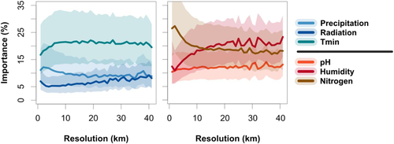

**Figure 3**

Open in figure viewer[PowerPoint](https://onlinelibrary.wiley.com/action/downloadFigures?id=ecog12912-fig-0003&doi=10.1111%2Fecog.05973)

Relative importance (%) of individual climate and soil predictors in calibrating ensemble models of 1180 plant species for 41 resolutions (100-m to 40-km). Importance was obtained by applying the median (main lines) and 25% and 75% quantiles (lower and upper lines) across models. Precipitation: ‘annual precipitation sum'; Radiation: ‘annual solar radiation'; Tmin: ‘minimum temperature of coldest month'; pH: ‘soil pH'; Humidity: ‘soil Humidity'; Nitrogen: ‘soil nitrogen'.

Scatterplots of extracted values per species between 100-m and 10-km differed less for climatic than for soil predictors, except for Radiation which remained strongly transformed at the coarser resolution (Supporting information). All soil predictors (pH, Nitrogen and Humidity) were indeed found to lose more crispness of environmental information than climate predictors when shifting from a 100-m to a 10-km resolution. As an example, species generally occurring in low pH environments (acidophilous) tended to sample more alkaline values at the 10-km compared to the 100-m resolution, while species generally occurring in high pH environments (basophilous) sampled more acidic values.

Predicted multifaceted diversity between 100-m (aggregated) and 1-km resolutions highlighted strong divergence patterns of TD/rPD/rFD (Fig. 4) with a strong under-estimation of TD at 1-km resolution, for all models independent of the predictor set used. Indeed, spatial relationships between 100-m (aggregated) and 1-km for rPD, rFD and TD layers showed very weak to medium correlation for CLIM–SOIL (R<sup>2</sup> = 0.13, 0.49 and 0.57 respectively; Fig. 4), CLIM and SOIL models (R<sup>2</sup> = 0.05–0.74; Supporting information). Overall, similar results were found for comparative multifaceted diversity at 10, 20, 30 and 40-km resolution, although correlations between layers highly decreased with decreasing resolution (Supporting information).

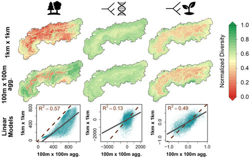

**Figure 4**

Open in figure viewer[PowerPoint](https://onlinelibrary.wiley.com/action/downloadFigures?id=ecog12912-fig-0004&doi=10.1111%2Fecog.05973)

Predicted TD, rPD and rFD distribution of 1109 species for CLIM-SOIL models (from left to right) at 1-km and 100-m resolution (first and second row). Diversity distributions mapped at 100-m resolution were generated based on the aggregation of species distributions from 100-m to 1-km resolution (100 × 100 m agg.), and compared to diversity distributions mapped at 1-km resolution (1 × 1 km). TD, rPD and rFD define here the number of species, the excess/deficit of phylogenetic and functional diversity compared to TD, respectively. The third row highlights statistical relationships of the three diversity facets between the two 1-km map versions (these values in the legend are normalized from 0 to 1 for more clarity). Scatterplots were obtained by randomly sampling 100 000 pixels without replacement, and trend lines were obtained by fitting a linear regression (linear terms only) for which the adjusted R<sup>2</sup> gives the calibration strength (explained variance). A dotted line of intercept 0 and slope 1 was also drawn to represent over- and under-estimation of 1-km values comparably to that of 100-m (aggregated).

## Discussion

Here we demonstrate that SDMs projected to finer resolution led to better model performances and different detections of multifaceted diversity. Our results confirm previous studies identifying improved model performances at finer resolution for sessile species (Guisan et al. 2007, Seo et al. 2009, Pradervand et al. 2014, Manzoor et al. 2018), and uncover the amount of multifaceted diversity change between different resolutions. Indeed, finer resolutions not only led to higher predictive performance in general, but also to different predictions of multifaceted diversity (Fig. 4). Few studies have already shown that increasing spatial resolution of predictors improves the accuracy of plant species predictions and – due to higher spatial details – predict increased microrefugias and persistence under climate change (Randin et al. 2009, Dobrowski 2011, Hannah et al. 2014, Lenoir et al. 2017, Meineri and Hylander 2017). In contrast, predictors presenting a lower resolution exhibit from less variability in their values which likely explains the poorer model performances. As resolution decreases, environmental information becomes fuzzier by including more errors, causing increasing uncertainties in the species response (also called ‘regression dilution'; McInerny and Purves 2011, Stoklosa et al. 2015). Our study extends these findings and demonstrates that finer resolution results in very different predictions of taxonomic, phylogenetic and functional diversities (Fig. 4), with strong divergences (0.13 ≤ R<sup>2</sup> ≤ 0.57) of diversity predictions between a 100-m and a 1-km resolution.

Differences in multifaceted biodiversity distributions found between finer and coarser resolutions indicate strong consequences for ecological studies implementing SDMs, as too coarse resolutions may lead to misleading predicted species distributions. For example, grains ≥ 1-km in SDM conservation studies of sessile species are relatively common. The decision to select such grains is often driven by coordinate accuracy or resolution of the species distribution data (Araújo et al. 2011, Niamir et al. 2011, Mateo et al. 2019, Zhang et al. 2019). Yet, other studies seem to indirectly motivate this choice by modelling multiple clades (Fajardo et al. 2014, Hällfors et al. 2016, Lehtomäki et al. 2019), and sometimes do not provide rationale despite accurate species observations (van Andel et al. 2015, Fois et al. 2018, Spiers et al. 2018, Manish and Pandit 2019). The strong diversity divergences found between resolutions suggests that conservation recommendations of such studies, based on predicted species distributions ≥ 1-km resolution, might be strongly biased and could mislead related decision-making; e.g. species reintroduction, conservation planning or ecosystem services protection. Although it could be argued that coarser-grained species distributions could still act as a sound proxy of finer-grained species distributions, such an assumption may implicitly be valid provided that patterns of diversity remain at both grains spatially similar. Yet, our findings show particularly weak correlations between coarser and finer diversities, especially for PD, which raises doubts about ecological studies that aim to assist decision making regarding species and diversity management of sessile organisms, if based on too coarsely predicted species distributions.

This divergence of diversity between resolutions is not surprising. A previous study has already demonstrated that multifaceted diversity built from aggregation of fine-scale species predictions to coarser resolution, gives more accurate estimates of actual community structures and diversity patterns (Thuiller et al. 2015). Here, the imprints of finer-scale dynamic processes (such as biotic interactions) are presumably implicitly integrated and community diversity becomes more representative (Kraft and Ackerly 2010, Thuiller et al. 2015, Chalmandrier et al. 2017). Said differently, the aggregation of fine-scale species distributions allows gamma diversity to be more truthfully represented, as opposed to the simple spatial average of multifaceted diversity from fine to coarser resolution (‘100 × 100 m mean'; Supporting information). Indeed, multifaceted diversity averaged from 100-m to 1-km remains very similar to the predicted multifaceted diversity at 1-km resolution (‘100 × 100 m mean' versus ‘1 × 1 km'; Supporting information). It similarly, highlights weak to average correlations with 100-m (aggregated) diversities, and seem to average down the local taxonomic alpha diversity causing an underestimation of gamma diversity (Supporting information). A comparative correlation analysis with expert-based plant diversity of the European Alps (Aeschimann et al. 2004) confirms this trend, and underlines that aggregating species distributions from 100-m to 1-km resolution allows the community structure and related gamma diversity to be better represented (r = ~0.7), compared to the averaged taxonomic diversity from 100-m to 1-km resolution (r = ~0.5) or the predicted taxonomic diversity at 1-km resolution (r = ~0.5; Supporting information). Interestingly, rPD and rFD are differently affected than TD when built from aggregation of fine-scale species predictions, as, unlike TD, lower rPD and rFD compared to coarser resolution were found towards low and high elevations, respectively (Supporting information). It seems that projecting species distribution to finer resolution, allowed, at the corresponding elevations, the evolutionary history and ecological role of communities to be adjusted down, due to larger predictions of genetically and functionally similar species.

Overall, the drop in model performance of soil predictors from 100-m to 1-km resolution was larger than of climate predictors (Fig. 2). This is explained by soil predictor values that are more altered from fine to coarse resolutions than climate predictor values (Supporting information). This confirms recent statements regarding the need of more highly resolved edaphic and topographic predictors, to improve the modelling of ecological patterns and processes (Buri et al. 2017, Lembrechts et al. 2019b, 2020, Scherrer and Guisan 2019). Independent of model predictive performances, the relative importance of climate and soil predictors in predicting plant distributions across resolutions remained contrasted (Fig. 3). Radiation, Precipitation and pH showed low but constant relative importance across grains, while Humidity, Tmin and Nitrogen seem to particularly drive species distributions at coarser, all and finer resolutions respectively. According to previous studies (Pradervand et al. 2014, Meineri and Hylander 2017, Lembrechts et al. 2019b, Scherrer and Guisan 2019), climate is thought to drive plant distribution at both fine and coarse resolutions, whereas soil properties are said to better explain this distribution at finer spatial resolution. Although the importance of Tmin and soil Nitrogen across grains seems to confirm this trend, the importance of soil Humidity on the contrary does not. However, soil conditions are known to be strongly influenced by climatic conditions (Teuling et al. 2007) especially in mountain environments (Chauvier et al. 2021a), and soil humidity is generally known to be related to precipitation (Koster et al. 2003, Sehler et al. 2019). On the one hand, this likely explains the increasing importance of soil humidity with coarser resolution, whose effect on predicting species distribution seems to confound strongly with precipitation. On the other hand, although we might have expected Humidity, like Precipitation, to have a greater influence at finer resolution, it seems that Nitrogen captures the whole fine scale soil variability in the model calibrations at the cost of Humidity.

Overall, we warn against modelling sessile species distributions at coarse resolution if finer predictors and species distribution data are available. Doing otherwise may lead to imprecise results from ecological studies supporting species and diversity management (e.g. species and population monitoring, species reintroduction, invasion ecology, conservation and ecosystem services planning), and provide misleading recommendations when assisting decision making. Realistic SDMs should normally include additional key local scale ecological factors, biotic interactions and dispersal limitations being the most crucial ones. While accounting for dispersal is increasingly feasible through supplementary modelling processes such as those dealt with in eco-evolutionary mechanistic models (Rangel et al. 2018, Hagen et al. 2021) or in empirical dispersal models (Engler et al. 2012), the inclusion of biotic interactions in SDMs faces numerous challenges (Kissling et al. 2012, Wisz et al. 2013, Pollock et al. 2014). Including species interactions would indeed allow community assembly to be predicted at finer spatial resolution, which would also aid more detailed species and diversity management. Despite increasing advances in this field, the best way of including biotic interactions remains uncertain (König et al. 2021, Poggiato et al. 2021). Therefore, ecological studies should meanwhile focus on implementing highly resolved predictors for improved spatial assessments of aggregated species and diversity distribution at local scales.

### Acknowledgements

– We thank all various contributors for sharing numerous datasets of species observations and traits, and for having made possible the large-scale scope of this study. We particularly thank Info Flora and the Conservatoire Botanique National Alpin, for their continuous effort in collecting and cleaning plant data across Switzerland and the French Alps.

### Funding

– This work was supported by the ANR-SNF bilateral project OriginAlps, with grant no. 310030L_170059 (Y.C., N.E.Z.) and no. ANR-16-CE93-004 (W.T., M.G., L.B.). W.T., M.G. and L.B. also acknowledge the Agence Nationale de la Recherche (ANR) through the ‘Investissement d'Avenir' grants managed by the ANR (Trajectories: ANR-15-IDEX-02; Montane: OSUG@2020: ANR-10-LAB-56).

### Author contributions

**Yohann Chauvier**: Conceptualization (lead); Data curation (lead); Formal analysis (lead); Investigation (lead); Methodology (lead); Software (lead); Writing – original draft (lead). **Patrice Descombes**: Conceptualization (supporting); Data curation (supporting); Formal analysis (supporting); Investigation (supporting); Methodology (supporting); Supervision (supporting); Writing – original draft (supporting). **Maya Guéguen**: Data curation (supporting); Methodology (supporting); Software (supporting). **Louise Boulangeat**: Data curation (supporting); Resources (supporting). **Wilfried Thuiller**: Conceptualization (supporting); Formal analysis (supporting); Funding acquisition (equal); Investigation (supporting); Methodology (supporting); Supervision (equal); Validation (supporting); Writing – original draft (supporting). **Niklaus E. Zimmermann** Conceptualization (supporting); Formal analysis (supporting); Funding acquisition (equal); Investigation (supporting); Methodology (supporting); Resources (supporting); Supervision (equal); Validation (supporting); Writing – original draft (supporting).

## Supporting information

The Supporting information associated with this article is available with the online version.

## References

[figure not shown]

[figure not shown]